# phytoplankton class prediction

Flavien

14/06/2021

The 3X1M sensor is a fluorometer with 3 different exciation channels (440, 470 and 532nm). The fluorescence signal correspond to different accesories pigment, that can be used as biomarker of different taxa. Experimentations have been conducted in the SBR to characterize the response of different mediterranean taxa of phytoplankton. From those data, it is possible to develope a model that classify the signal response directly in situ.

# Experimentation results

As we calculated the chlorophyll from spectrophotmetri in first place, we compared it with hplc measurement afterward.

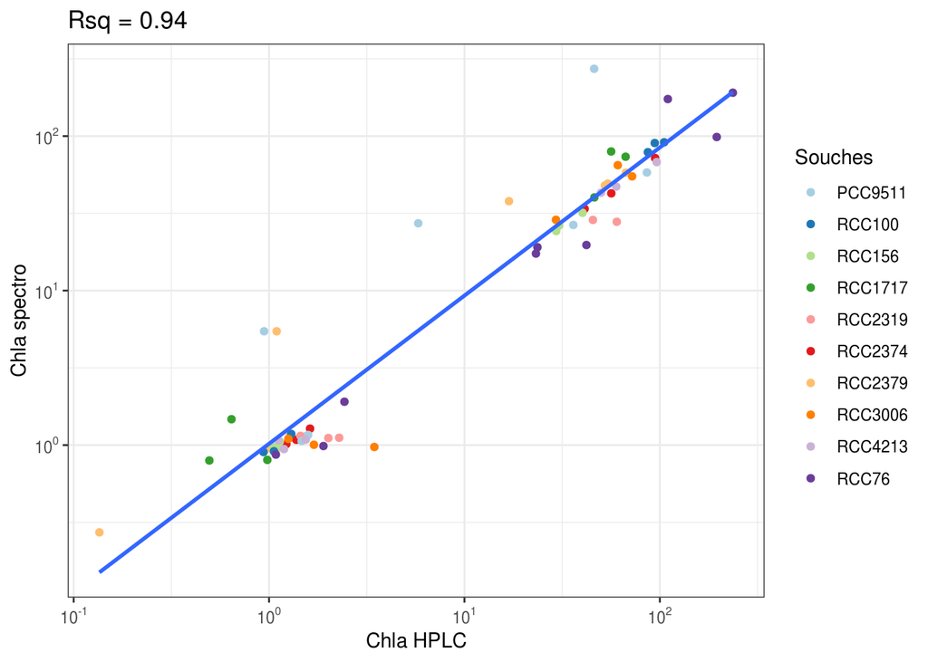

Figure: Chla HPLC compared to Chla estimated with spectro

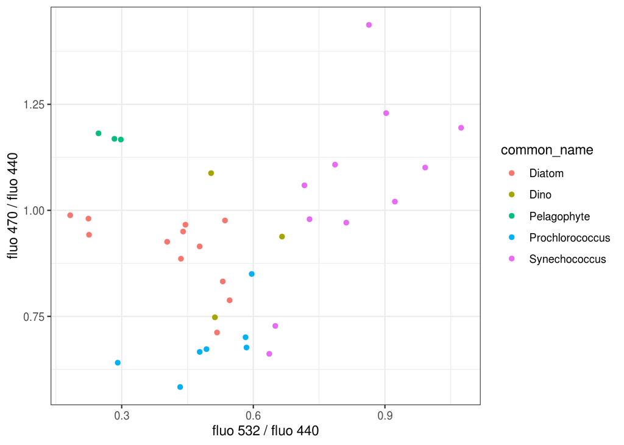

Figure: Distribution of phytoplankton groups

This figure indicated that it may be possible to dsicriminate the different phytoplankton groups with a linear discrimination analysis (LDA).

# LDA

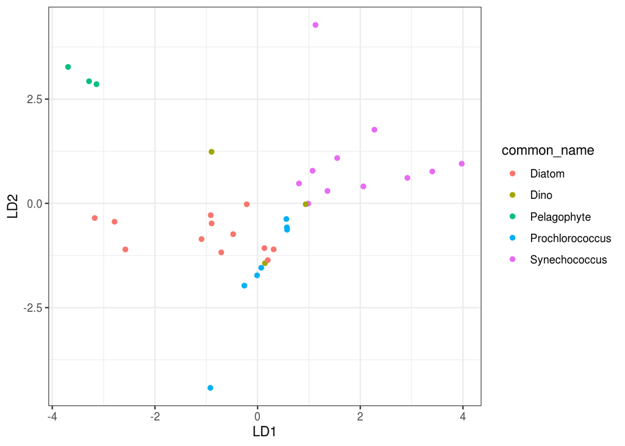

Figure: LDA plot of the dataset

A bootstrap technique was used (2/3 train 1/3 test) to create a confusion matrix to understand which class can be well predict or not.

```
##                  prediction
## ytest             Diatom Dino Pelagophyte Prochlorococcus Synechococcus
##   Diatom            1341    6           0             311             0
##   Dino               147    0           0             136           127
##   Pelagophyte          0    0         427               0             0
##   Prochlorococcus    223   64           0             643             8
##   Synechococcus        0   11          46             281          1229
```

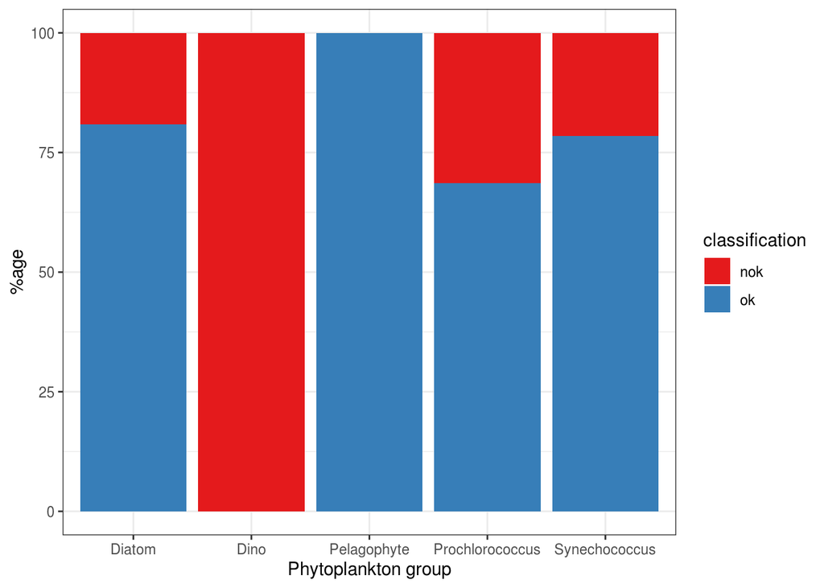

Figure: Percentage of good prediction from the LDA

The model is good to predict Diatom, Pelagophyte and Synechococcus, but is not powerfull enough to detect dinoflagellate and Prochlorococcus.

# Application

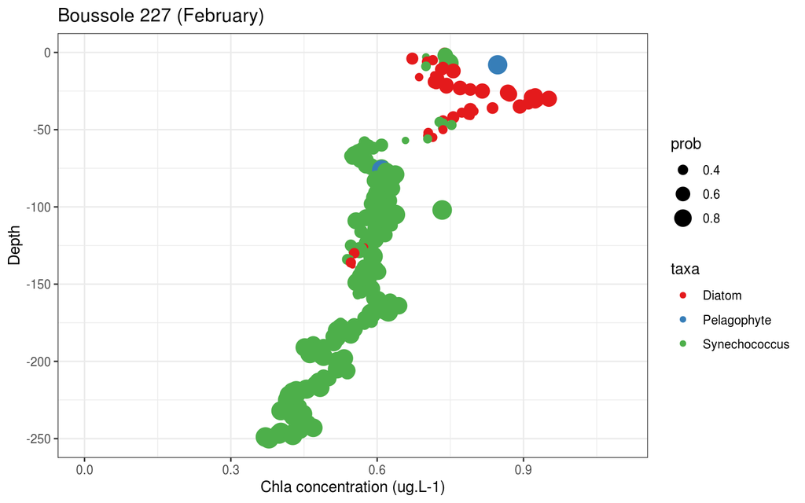

Figure: Prediction of phytoplankton group on a Boussole profile

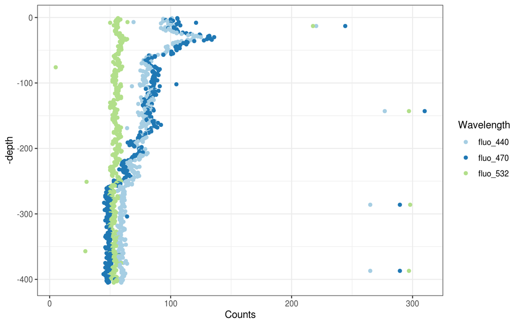

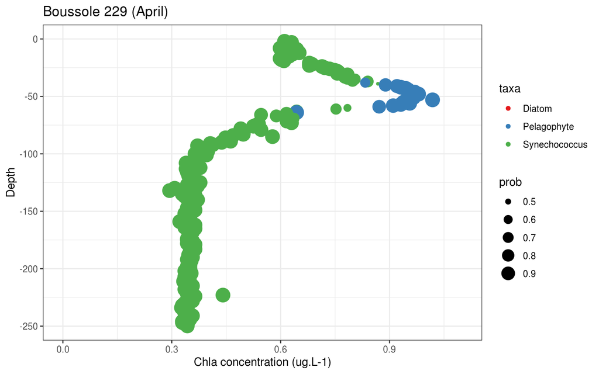

Figure: Prediction of phytoplankton group on a Boussole profile

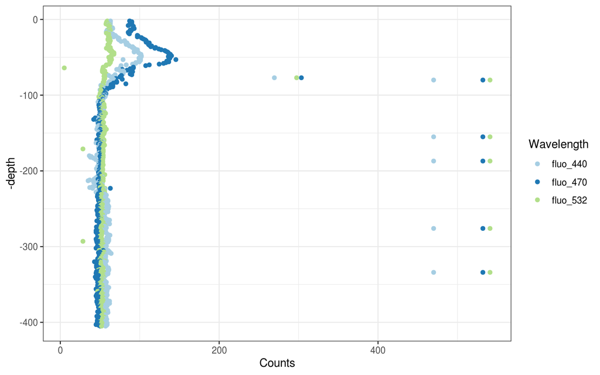

The plots show that the LDA discriminate different communities along the profile. Especially on the Chl maximum structure. However the community structure should be examined to determine the accuracy of this output. It seems that Synechoccus are over represented in the output, which can be due to better discrimination of this taxa with the 532 channel.